# Rapport d’analyse - Jeu de données Iris

Projet R1

24 February 2026

# Introduction

Ce rapport présente l’exploration, les statistiques descriptives et les visualisations du jeu de données **Iris** (Fisher, 1936), composé de 150 mesures de fleurs d’iris réparties en trois espèces. L’objectif est de comprendre la structure des données, les relations entre variables et les tendances par espèce.

# 1. Exploration et préparation des données

## 1.1 Structure du jeu de données

Le jeu contient **150** observations et **5** variables :

- **Sepal.Length**, **Sepal.Width**, **Petal.Length**, **Petal.Width** (en cm) ;
- **Species** : facteur à 3 niveaux (setosa, versicolor, virginica).

```r
str(iris)
```

```
## 'data.frame':    150 obs. of  5 variables:
##  $ Sepal.Length: num  5.1 4.9 4.7 4.6 5 5.4 4.6 5 4.4 4.9 ...
##  $ Sepal.Width : num  3.5 3 3.2 3.1 3.6 3.9 3.4 3.4 2.9 3.1 ...
##  $ Petal.Length: num  1.4 1.4 1.3 1.5 1.4 1.7 1.4 1.5 1.4 1.5 ...
##  $ Petal.Width : num  0.2 0.2 0.2 0.2 0.2 0.4 0.3 0.2 0.2 0.1 ...
##  $ Species     : Factor w/ 3 levels "setosa","versicolor",..: 1 1 1 1 1 1 1 1 1 1 ...
```

## 1.2 Valeurs manquantes

```r
colSums(is.na(iris))
```

```
## Sepal.Length  Sepal.Width Petal.Length  Petal.Width      Species
##            0            0            0            0            0
```

**Conclusion :** Aucune valeur manquante ; le jeu est complet.

## 1.3 Répartition par espèce

```r
table(iris$Species)
```

```
##
##     setosa versicolor  virginica
##         50         50         50
```

Les trois espèces sont **équilibrées** (50 observations chacune).

# 2. Statistiques descriptives et corrélations

## 2.1 Tendance centrale et dispersion

```r
iris %>%
  group_by(Species) %>%
  summarise(
    N = n(),
    Moy_Sepal.L = round(mean(Sepal.Length), 2), SD_Sepal.L = round(sd(Sepal.Length), 2),
    Moy_Petal.L = round(mean(Petal.Length), 2), SD_Petal.L = round(sd(Petal.Length), 2),
    .groups = "drop"
  ) %>%
  knitr::kable()
```

| Species | N | Moy_Sepal.L | SD_Sepal.L | Moy_Petal.L | SD_Petal.L |
| --- | --- | --- | --- | --- | --- |
| setosa | 50 | 5.01 | 0.35 | 1.46 | 0.17 |
| versicolor | 50 | 5.94 | 0.52 | 4.26 | 0.47 |
| virginica | 50 | 6.59 | 0.64 | 5.55 | 0.55 |

**Insight :** Setosa a des pétales plus petits en moyenne ; Virginica des mesures plus grandes.

## 2.2 Corrélations

```r
round(cor(iris[, 1:4]), 3)
```

```
##              Sepal.Length Sepal.Width Petal.Length Petal.Width
## Sepal.Length        1.000      -0.118        0.872       0.818
## Sepal.Width        -0.118       1.000       -0.428      -0.366
## Petal.Length        0.872      -0.428        1.000       0.963
## Petal.Width         0.818      -0.366        0.963       1.000
```

## 2.3 Heatmap des corrélations

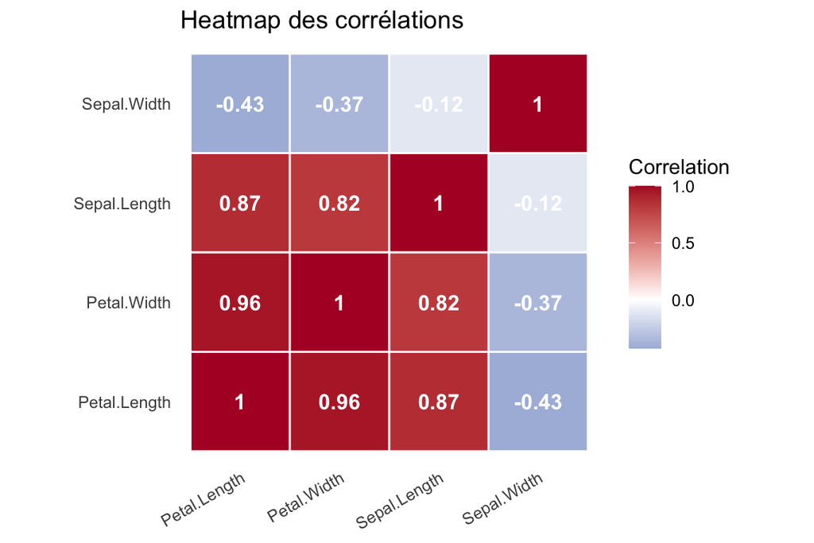

Heatmap des corrélations entre variables numériques.

```r
mat_cor <- cor(iris[, 1:4])
mat_cor_df <- as.data.frame(mat_cor)
mat_cor_df$Var1 <- rownames(mat_cor_df)
mat_cor_long <- mat_cor_df %>%
  tidyr::pivot_longer(-Var1, names_to = "Var2", values_to = "Correlation")

ggplot(mat_cor_long, aes(x = Var1, y = Var2, fill = Correlation)) +
  geom_tile(color = "white", linewidth = 0.5) +
  geom_text(aes(label = round(Correlation, 2)), color = "white", size = 4, fontface = "bold") +
  scale_fill_gradient2(low = "#2166ac", mid = "white", high = "#b2182b", midpoint = 0) +
  labs(title = "Heatmap des corrélations", x = NULL, y = NULL) +
  theme(axis.text.x = element_text(angle = 30, hjust = 1), panel.grid = element_blank()) +
  coord_fixed()
```

# 3. Visualisations et tendances

## 3.1 Histogrammes

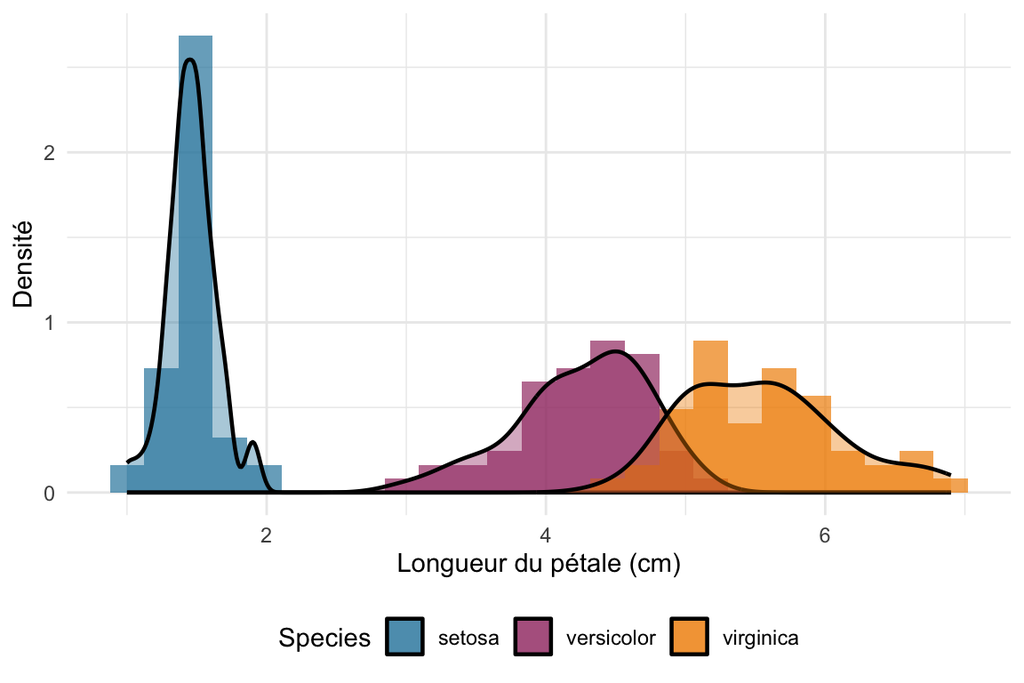

Distribution de la longueur du pétale par espèce.

```r
ggplot(iris, aes(x = Petal.Length, fill = Species)) +
  geom_histogram(aes(y = after_stat(density)), bins = 25, alpha = 0.7, position = "identity") +
  geom_density(alpha = 0.4, linewidth = 0.8) +
  scale_fill_manual(values = palette_especes) +
  labs(x = "Longueur du pétale (cm)", y = "Densité") +
  theme(legend.position = "bottom")
```

## 3.2 Boxplots et outliers

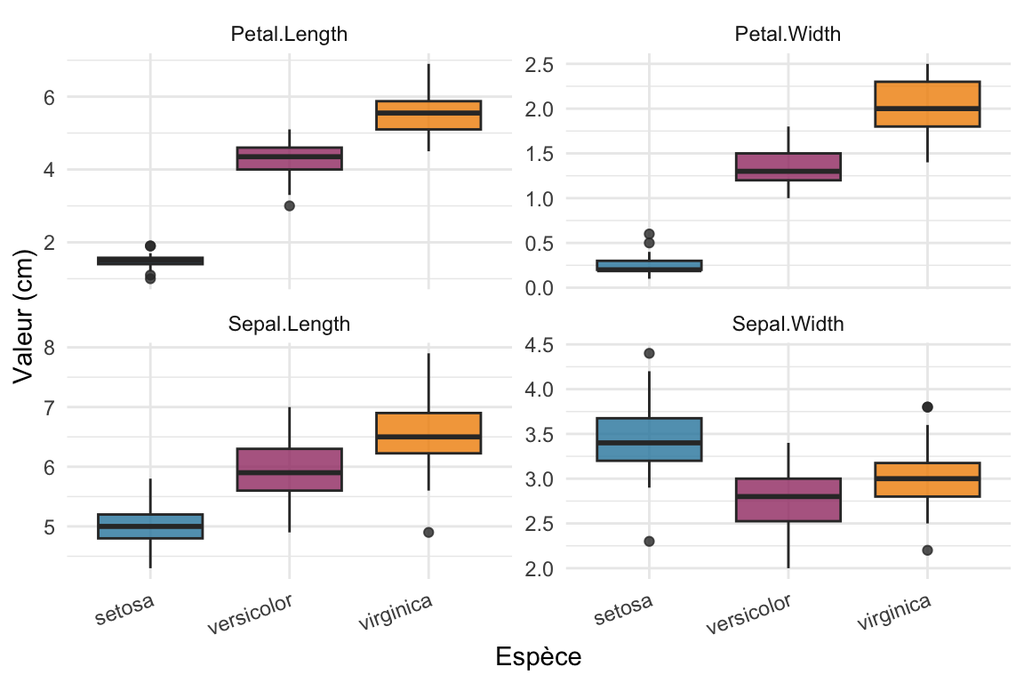

Boxplots par espèce pour chaque variable.

```r
iris_long <- iris %>%
  pivot_longer(cols = Sepal.Length:Petal.Width, names_to = "Variable", values_to = "Valeur_cm")

ggplot(iris_long, aes(x = Species, y = Valeur_cm, fill = Species)) +
  geom_boxplot(alpha = 0.8) +
  facet_wrap(~ Variable, scales = "free_y", ncol = 2) +
  scale_fill_manual(values = palette_especes) +
  labs(x = "Espèce", y = "Valeur (cm)") +
  theme(legend.position = "none", axis.text.x = element_text(angle = 20, hjust = 1))
```

**Analyse :** Différences nettes entre espèces ; quelques outliers (ex. Sepal.Width) sans remettre en cause les tendances.

## 3.3 Scatter plot et séparation des espèces

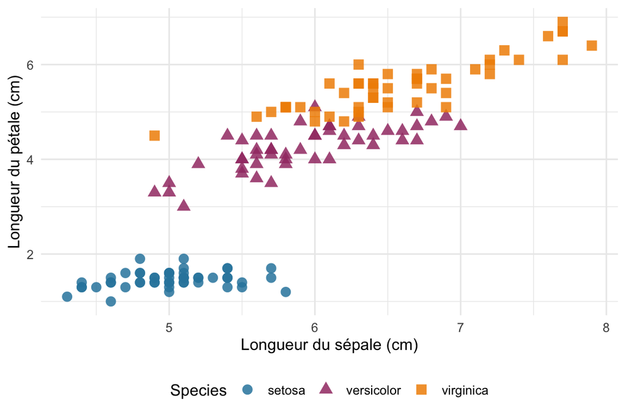

Séparation des espèces dans le plan Sépale–Pétale.

```r
ggplot(iris, aes(x = Sepal.Length, y = Petal.Length, color = Species, shape = Species)) +
  geom_point(size = 3, alpha = 0.85) +
  scale_color_manual(values = palette_especes) +
  labs(x = "Longueur du sépale (cm)", y = "Longueur du pétale (cm)") +
  theme(legend.position = "bottom")
```

**Réponses à la problématique :**

- Les espèces sont **bien séparées** sur le scatter plot, surtout setosa.
- **Patterns pour la classification :** Petal.Length et Petal.Width discriminent bien setosa ; la combinaison Sepal.Length × Petal.Length aide à distinguer versicolor et virginica.

# 4. Synthèse et conclusions

| Point | Conclusion |
| --- | --- |
| Structure | 150 observations, 4 variables numériques, 1 facteur ; pas de NA. |
| Espèces | Équilibre parfait (50 par espèce). |
| Corrélations | Petal.Length et Petal.Width très corrélés ; liens forts avec Sepal.Length. |
| Tendance centrale | Setosa : pétales plus petits ; Virginica : mesures en moyenne plus grandes. |
| Outliers | Quelques points atypiques (ex. Sepal.Width), impact limité. |
| Séparation | Setosa bien séparée ; versicolor et virginica partiellement chevauchantes. |
| Classification | Variables les plus discriminantes : **Petal.Length**, **Petal.Width**. |

*Rapport généré avec R Markdown. Code et graphiques produits avec R et ggplot2.*